# Analysis adolescent Fertility rates Final Project Data 606

2022-11-29

## Abstract

I recently read an article in “The New York Times” about the problems of teenage pregnancies. The article mentioned that there are countries where teenage pregnancy is common. I decided to review which are the countries that have the most impact on this topic.

The questions I asked myself were the following:

-Which countries have the highest adolescent fertility rates and which countries have the lowest adolescent fertility rates?

-Is there a relationship between economic indicators for women in the country with fertility rates in adolescents?

## Data Collection

The dataset that I used can be found on the page The world bank. The World Bank collects data from each country year after year of the fertility rate in adolescents aged 15 to 19 years. It is discriminated by each country in the world and the data is indicated from the year 1960 to 2015. I also queried the dataset: World Development Indicators: Women and Development, to analyze the relationship of the fertility rates of each country with the economic indicators for women of each country.

The World Bank:

https://data.worldbank.org/indicator/SP.ADO.TFRT

## Data

**Type of study**

This study is of an observational type, because I am going to analyze the data that the dataset has on the fertility rate in adolescents aged 15 to 19, from the year 1960 to the year 2015.

**Dependent Variable**

The dependet variable is quantitative.The response variable is the weighted average number of births per 1,000 adolescent women aged 15 to 19 for each country.

Variable name: adolescent_fertility_rates

## Data

**Independent Variable**

The independent variables are the economic indicators for women, for example in the dataset it indicates: Women who were first married by age 18, Account ownership at a financial institution of female (% of population ages 15 +), and survival to age 65.

Variables names: survival_female, survival_male, unemployment_youth_female, employment_youth_female, employment_female, labor_force, salaried_female.

## Research question

I asked myself the following:

-Which countries have the highest adolescent fertility rates and which countries have the lowest adolescent fertility rates?

-Is there a relationship between economic indicators for women in the country with fertility rates in adolescents?

## Summary statistics

I did perform the analysis to find the countries with the highest adolescent fertility rates and countries have the lowest adolescent fertility rates.

I decided to graph the 5 countries with the highest rates and the 5 countries with the lowest rates.

In the statistical analysis that we are going to carry out, we are going to take only the country with the highest fertility rate in adolescents and the country with the lowest fertility rate in adolescents.

## Graph - Hightest

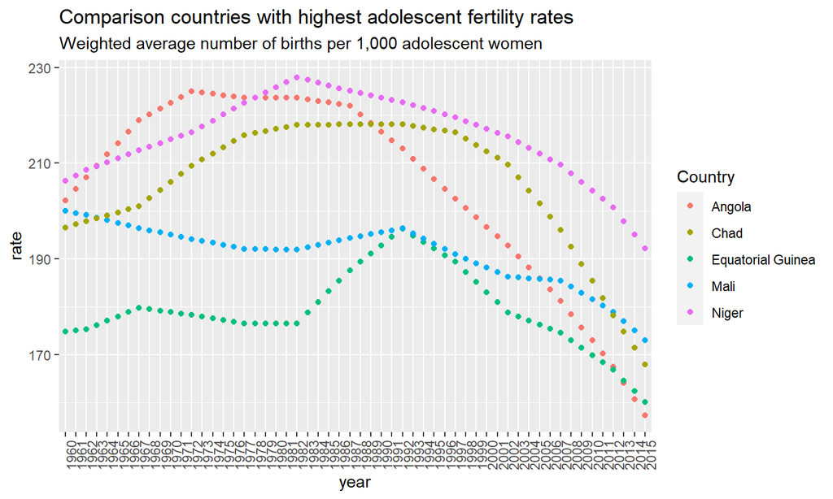

## Graph - Lowest

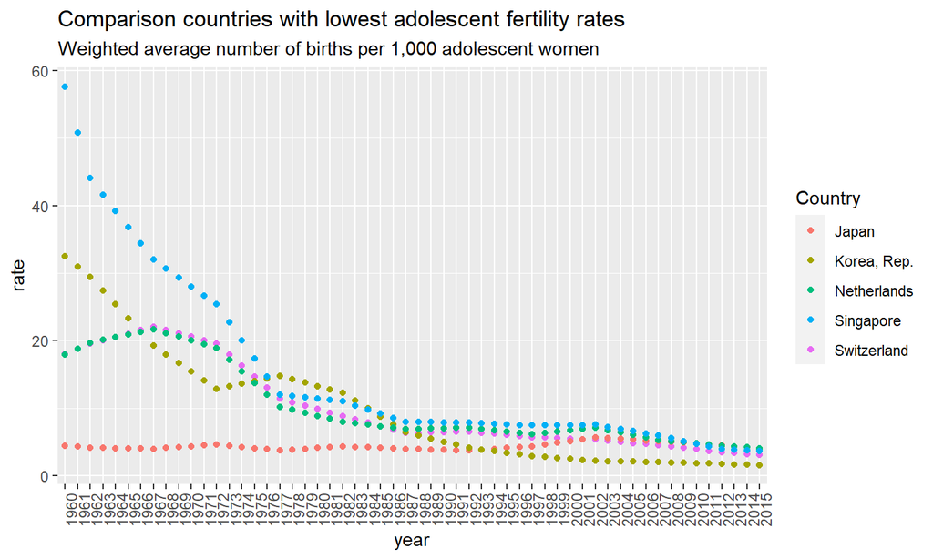

## Statistical

How is the behavior of the adolescents fertility rate in worldwide?

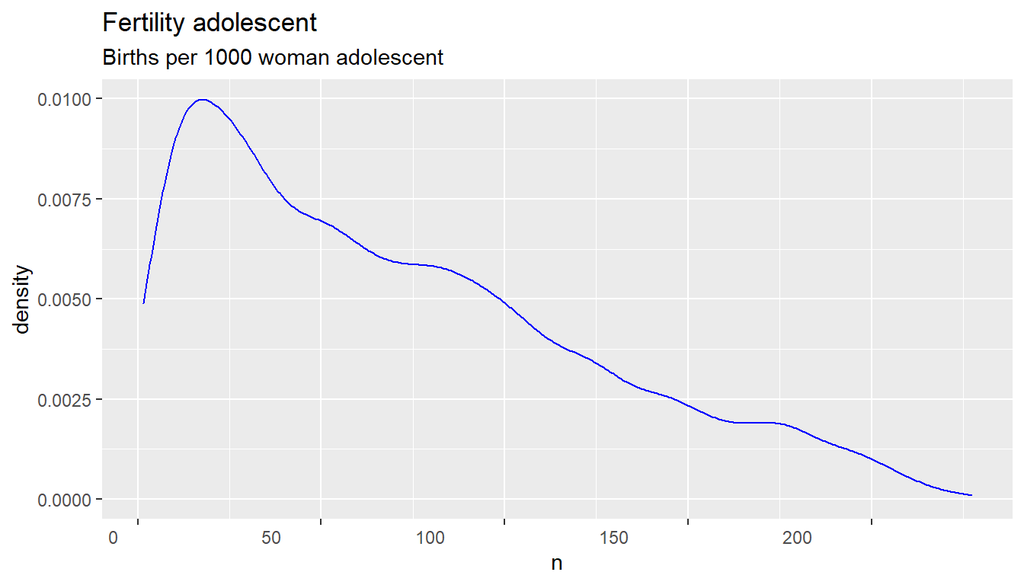

I did choose an independent variable, which is the 65-year survival rate, to perform a linear regression. I did compare if there is a relationship between the fertility rate in adolescents and the indicator of survival up to 65 years. Regression model used LM (linear model)

```
##
## Call:
## lm(formula = fertility_rate ~ survival_male + survival_female,
##     data = analysis_total)
##
## Residuals:
##      Min       1Q   Median       3Q      Max
## -152.300  -20.307   -4.707   21.988  112.540
##
## Coefficients:
##                  Estimate Std. Error t value Pr(>|t|)
## (Intercept)     245.61292    1.70745  143.85   <2e-16 ***
## survival_male     0.97001    0.08566   11.32   <2e-16 ***
## survival_female  -3.27642    0.08006  -40.93   <2e-16 ***
## ---
## Signif. codes:  0 '***' 0.001 '**' 0.01 '*' 0.05 '.' 0.1 ' ' 1
##
## Residual standard error: 32.17 on 6829 degrees of freedom
##   (8064 observations deleted due to missingness)
## Multiple R-squared:  0.6189, Adjusted R-squared:  0.6188
## F-statistic:  5545 on 2 and 6829 DF,  p-value: < 2.2e-16
```

**The equation is:**

\[ \hat{y} \ ( fertility\_adolescent) = 245.61292 \ + \ 0.97001 \ * \ survival_male \ - \ 3.27642 \ * \ survival_female \]

Survival variables for both men and women are correlated with fertility rates in adolescent women. Births per 1000 adolescent women is 245.61. As male survival increases, births increase by 0.97001. And as female survival increases, births decrease by 3.27642. This could be due to the fact that the more adult women there are, it can influence a little that decreases the adolescent fertility in women.

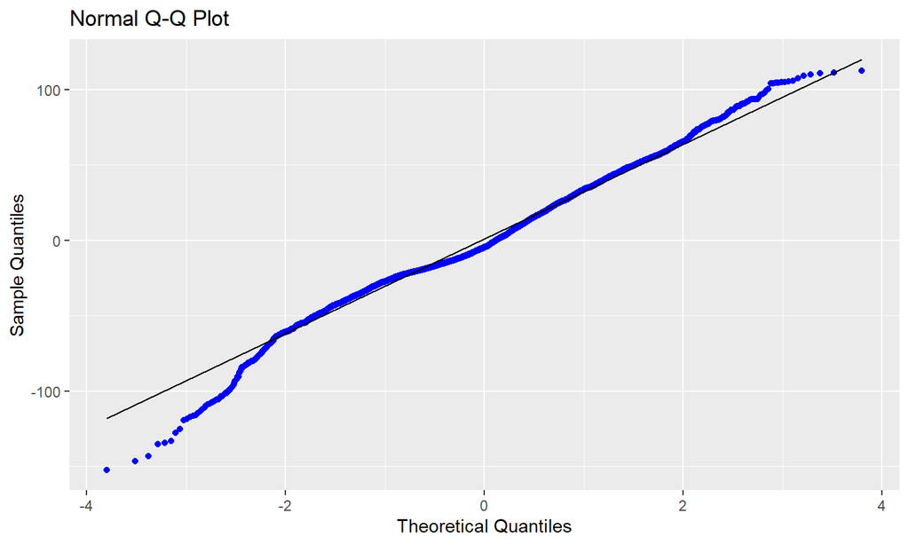

Analyzing the graphs the result is a normal distribution skewed to the left.

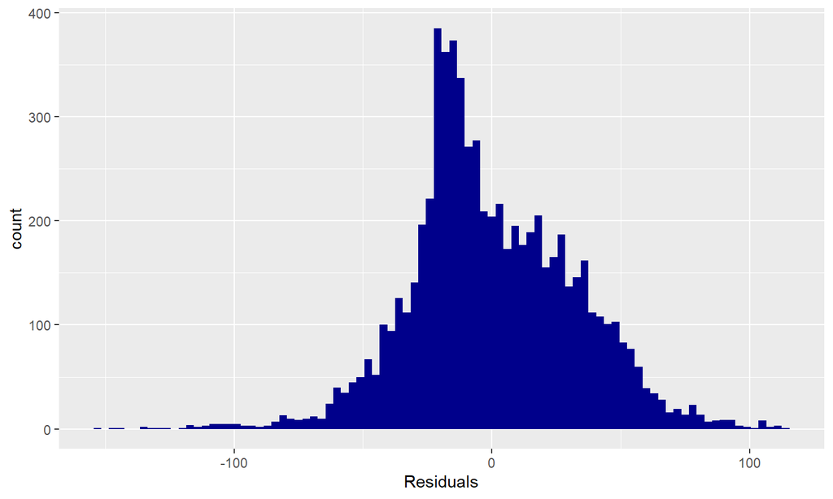

I did perform the analysis for the country with the highest adolescent fertility rate

[figure not shown]

## Statistical - NIGERIA

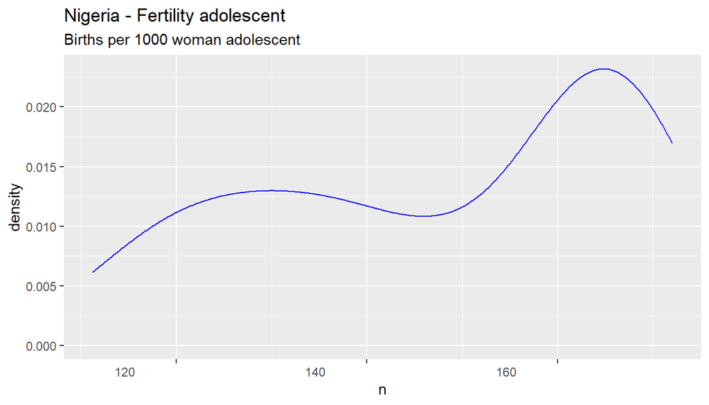

## Statistical - NIGERIA

I did choose an independent variable, which is the 65-year survival rate, to perform a linear regression. I did compare if there is a relationship between the fertility rate in adolescents and the indicator of survival up to 65 years. Regression model used LM (linear model)

```
##
## Call:
## lm(formula = fertility_rate ~ survival_male + survival_female,
##     data = niger_survival)
##
## Residuals:
##      Min       1Q   Median       3Q      Max
## -14.0016  -4.5474   0.1216   4.4023  11.9396
##
## Coefficients:
##                 Estimate Std. Error t value Pr(>|t|)
## (Intercept)      112.771     14.062   8.019 1.04e-10 ***
## survival_male    -18.994      1.456 -13.046  < 2e-16 ***
## survival_female   17.509      1.585  11.048 2.30e-15 ***
## ---
## Signif. codes:  0 '***' 0.001 '**' 0.01 '*' 0.05 '.' 0.1 ' ' 1
##
## Residual standard error: 6.582 on 53 degrees of freedom
## Multiple R-squared:  0.888,  Adjusted R-squared:  0.8838
## F-statistic: 210.1 on 2 and 53 DF,  p-value: < 2.2e-16
```

## Statistical - NIGERIA

**The equation is:**

\[ \hat{y} \ ( Niger\_fertility\_adolescent) = 112.771 \ - \ 18.994 \ * \ survival\_male \]

\[ \ + \ 17.509 \ * \ survival\_female \]

In Nigeria the births per 1000 adolescent women is 112.71.As male survival increases, births decrease by 18,994.And as female survival increases, births increase by 17,509. This could be due to socio-economic issues, according to the article “Outcome of Teenage Pregnancy in the Niger Delta of Nigeria” of the Ethiopian Journal of Health Science, adolescent pregnancies are concentrated in women of low economic levels and with less formal education .

https://www.ncbi.nlm.nih.gov/pmc/articles/PMC3437979/

## Statistical - NIGERIA

In the following graph we can see that the fertility rate in adolescents is much higher than the total fertility of women in Nigeria. Additionally, we can observe the relationship with life expectancy at birth and the survival rate at 65 years.

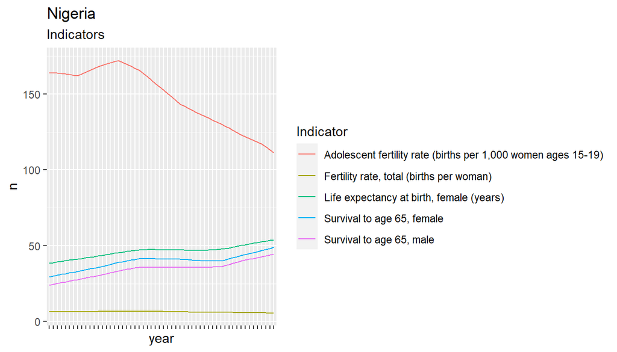

## Backward elimination

I analyzed the data set for women of the Nigeria, related to employment.

```
##
## Call:
## lm(formula = fertility_rate ~ employment_female + labor_force +
##     salaried_female, data = niger_employment)
##
## Residuals:
##    Min     1Q Median     3Q    Max
## -6.995 -1.837  0.306  2.002  4.149
##
## Coefficients:
##                   Estimate Std. Error t value Pr(>|t|)
## (Intercept)       763.3636   149.2547   5.115 4.58e-05 ***
## employment_female   2.9347     0.6560   4.473 0.000209 ***
## labor_force       -16.0342     3.7688  -4.254 0.000354 ***
## salaried_female    -4.2344     0.3152 -13.435 8.82e-12 ***
## ---
## Signif. codes:  0 '***' 0.001 '**' 0.01 '*' 0.05 '.' 0.1 ' ' 1
##
## Residual standard error: 2.869 on 21 degrees of freedom
##   (31 observations deleted due to missingness)
## Multiple R-squared:  0.9286, Adjusted R-squared:  0.9184
## F-statistic: 91.03 on 3 and 21 DF,  p-value: 3.372e-12
```

## Backward elimination

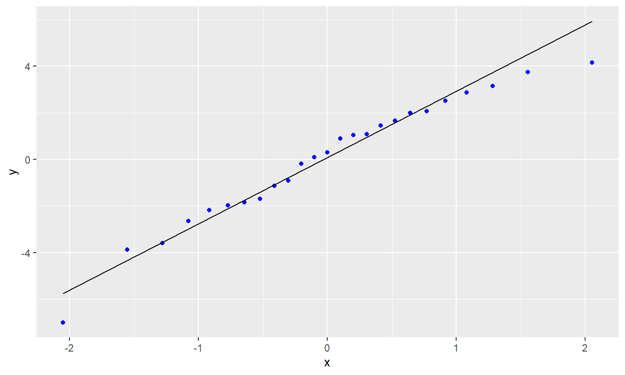

## Backward elimination

```
##
## Call:
## lm(formula = fertility_rate ~ employment_youth_female, data = niger_employment)
##
## Residuals:
##     Min      1Q  Median      3Q     Max
## -13.723  -4.985   1.035   5.431  13.030
##
## Coefficients:
##                         Estimate Std. Error t value Pr(>|t|)
## (Intercept)              54.7851    18.0747   3.031 0.005941 **
## employment_youth_female   2.7985     0.6819   4.104 0.000435 ***
## ---
## Signif. codes:  0 '***' 0.001 '**' 0.01 '*' 0.05 '.' 0.1 ' ' 1
##
## Residual standard error: 7.794 on 23 degrees of freedom
##   (31 observations deleted due to missingness)
## Multiple R-squared:  0.4227, Adjusted R-squared:  0.3976
## F-statistic: 16.84 on 1 and 23 DF,  p-value: 0.0004345
```

(JAPAN)

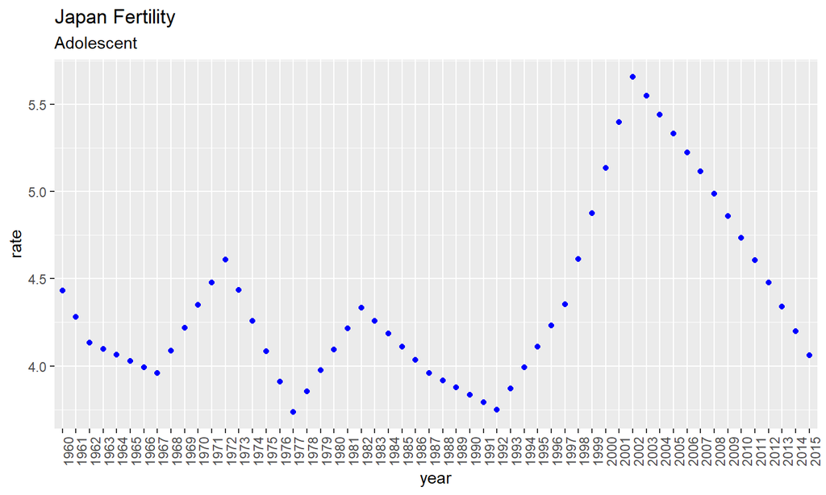

## Statistical - JAPAN

I did perform the analysis for the country with the lowest adolescent fertility rate:

## Statistical - JAPAN

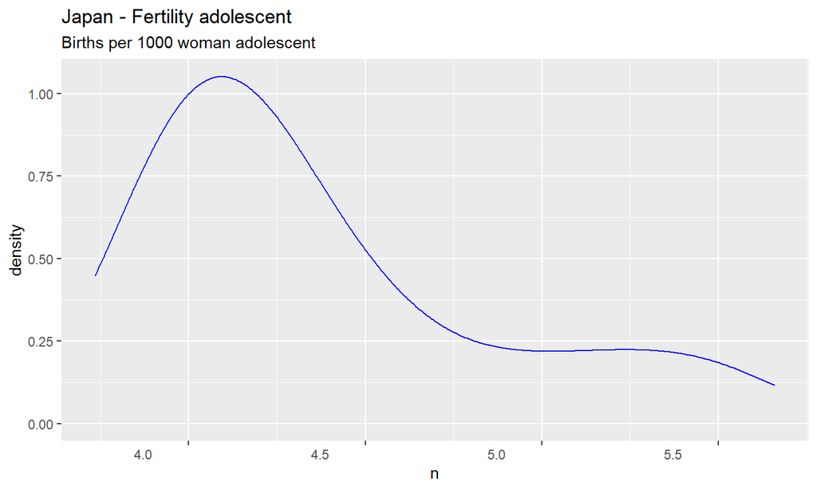

## Statistical - JAPAN

**The equation is:**

## Statistical - JAPAN

In the following graph we can see that the fertility rate in adolescents is very low, and is similar to the total fertility of women in Japan. Additionally, we can observe the relationship with life expectancy at birth and the survival rate at 65 years, both indicators are very similar.

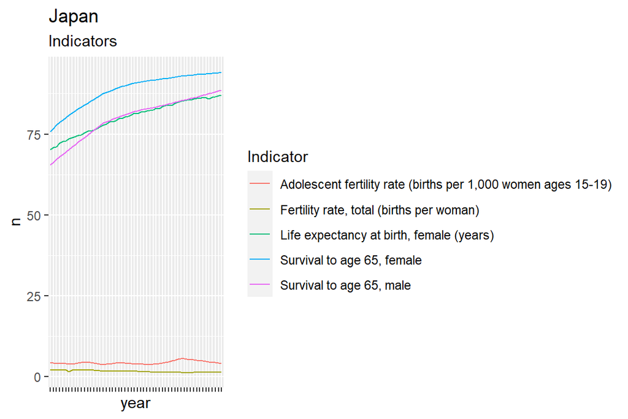

## Backward elimination

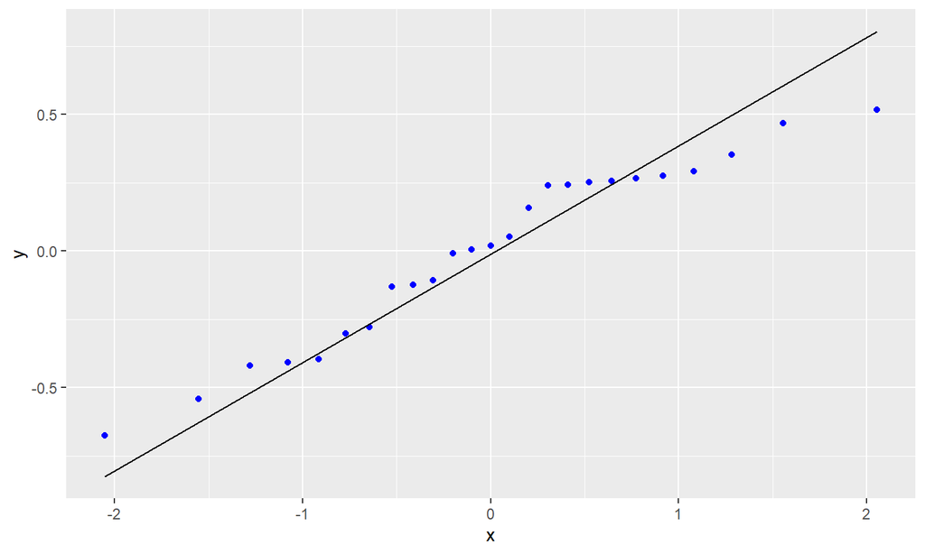

## Conclusion

Using the data set from The world bank, determine that

The countries with the highest birth rate in adolescents are:

-Niger

-Mali

-Chad

-Equatorial Guinea

-Angola

## Conclusion

The countries with the lowest adolescent birth rate are:

-Korea

-Switzerland

-Singapore

-Netherlands

-Japan

## Conclusion

When I started this study I thought I was going to have to find a correlation between the fertility rates of the countries with the economic indicators.

One of the questions raised was:

-Is there a relationship between economic indicators for women in the country with fertility rates in adolescents?

If they can contribute something, but it is not the main reason for a country to have more or less fertility rates in adolescents.

## Conclusion

There are many reasons that can affect a country to have high fertility rates in adolescents, education, economics, cultural issues or traditions, or the sum of different aspects of the country.

This analysis is important because fertility prevention initiatives can be created for adolescents in developing countries.

The main limitations are that information on some indicators is missing for some countries or specific years. The world bank depends on the data provided by each government or official organizations of each country, but in many cases these data are incomplete.